# R Notebook

This is a test of a hierarchical d model using Stan. First we load data and packages.

```r
library(tidyverse)
library(rstan)
library(readxl)
tACS_Data <- read_excel("~/GitHub/IntExtTACS/data/tACSData 1-21.xlsx", sheet = "RawData")
tACS_Data <- tACS_Data %>%
  filter(`TrialType[Trial]` != "NULL") %>%
  mutate(Stimulation = factor(.$Group, labels = c("Sham","Active")),
         Session = factor(.$Session, labels = c("First","Second")),
         Light = factor((`TrialType[Trial]` == "light" | `TrialType[Trial]` == "bothWeak") + 0,
                        levels = c(1, 0),
                        labels = c("Light","No light")),
         Touch = factor((`TrialType[Trial]` == "Weak" | `TrialType[Trial]` == "bothWeak") + 0,
                        levels = c(1, 0),
                        labels = c("Touch","No touch")),
         Response = ordered(.$`ResponsePrompt.RESP[Trial]`,
                           levels = c(4, 5, 6, 7),
                           labels = c("Definitely yes", "Maybe yes", "Maybe no", "Definitely no")),
         Reported = (.$`ResponsePrompt.RESP[Trial]` < 6)+0,
         Accuracy = ((Reported == 1 & Touch == "Touch") | (Reported == 0 & Touch == "No touch")) + 0,
         Confidence = factor((Response == "Definitely yes" | Response == "Definitely no") + 0,
                             levels = c(1, 0),
                             labels = c("Definitely", "Maybe"))
  )
```

To keep things simple, we’ll start by selecting data from the the Light and Sham conditions only, and keep only the columns Subject, Reported, and Touch.

```r
test_data <- filter(tACS_Data, Stimulation == "Sham", Light == "Light") %>%
  select(Subject, Reported, Touch)
test_data
```

| Subject | Reported | Touch |
| --- | --- | --- |
| 1 | 0 | No touch |
| 1 | 1 | Touch |
| 1 | 0 | Touch |
| 1 | 0 | No touch |
| 1 | 0 | No touch |
| 1 | 0 | No touch |
| 1 | 0 | Touch |
| 1 | 0 | Touch |
| 1 | 0 | Touch |
| 1 | 0 | No touch |

[output cut: 990 more lines]

Let’s convert that into counts.

```r
test_counts <- test_data %>%
  group_by(Subject, Touch) %>%
  summarise(totals = sum(Reported), trial_count = n())
test_counts
```

| Subject | Touch | totals | trial_count |
| --- | --- | --- | --- |
| 1 | Touch | 26 | 51 |
| 1 | No touch | 1 | 51 |
| 2 | Touch | 9 | 51 |
| 2 | No touch | 3 | 51 |
| 3 | Touch | 18 | 51 |
| 3 | No touch | 11 | 51 |
| 4 | Touch | 35 | 51 |
| 4 | No touch | 6 | 51 |
| 5 | Touch | 37 | 51 |
| 5 | No touch | 0 | 51 |

[output cut: 32 more lines]

We now have two rows per participant, one for “hits”, one for “false alarms”. It’d be nice to have standard, max likelihood estimates of d-prime. Some of the participants make no false alarms or have 100% hit rates. This causes trouble for the MLE. We can add a constant to the totals and trial_count to effectively correct that.

```r
test_counts$totals <- test_counts$totals + .5
test_counts$trial_count <- test_counts$trial_count + 1
test_counts
```

| Subject | Touch | totals | trial_count |
| --- | --- | --- | --- |
| 1 | Touch | 26.5 | 52 |
| 1 | No touch | 1.5 | 52 |
| 2 | Touch | 9.5 | 52 |
| 2 | No touch | 3.5 | 52 |
| 3 | Touch | 18.5 | 52 |
| 3 | No touch | 11.5 | 52 |
| 4 | Touch | 35.5 | 52 |
| 4 | No touch | 6.5 | 52 |
| 5 | Touch | 37.5 | 52 |
| 5 | No touch | 0.5 | 52 |

[output cut: 32 more lines]

We can convert those totals into hit and false alarms rates and from there compute d-prime.

```r
d_prime_MLE <- test_counts %>%
  mutate(rate = totals/trial_count) %>%
  select(Subject, Touch, rate) %>%
  spread(Touch,rate) %>%
  mutate(d_prime = qnorm(Touch)-qnorm(`No touch`),
         c_raw = -0.5*(qnorm(Touch) + qnorm(`No touch`)),
         c_prime = c_raw/d_prime)
d_prime_MLE
```

| Subject | Touch | No touch | d_prime | c_raw | c_prime |
| --- | --- | --- | --- | --- | --- |
| 1 | 0.50961538 | 0.028846154 | 1.92213318 | 0.9369621 | 0.48745949 |
| 2 | 0.18269231 | 0.067307692 | 0.59099440 | 1.2006497 | 2.03157538 |
| 3 | 0.35576923 | 0.221153846 | 0.39851148 | 0.5690464 | 1.42792980 |
| 4 | 0.68269231 | 0.125000000 | 1.62559013 | 0.3375543 | 0.20765032 |
| 5 | 0.72115385 | 0.009615385 | 2.92729979 | 0.8773772 | 0.29972237 |
| 6 | 0.97115385 | 0.009615385 | 4.23905579 | 0.2214992 | 0.05225202 |
| 7 | 0.14423077 | 0.048076923 | 0.60229016 | 1.3626477 | 2.26244393 |
| 8 | 0.33653846 | 0.009615385 | 1.91909825 | 1.3814780 | 0.71985789 |
| 9 | 0.45192308 | 0.009615385 | 2.22022298 | 1.2309156 | 0.55441082 |
| 10 | 0.14423077 | 0.163461538 | -0.08117228 | 1.0209165 | -12.57715716 |

[output cut: 11 more lines]

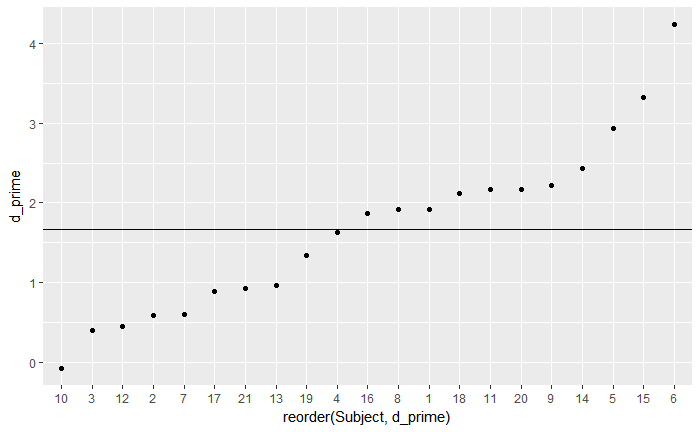

```r
ggplot(d_prime_MLE, aes(x = reorder(Subject, d_prime), y = d_prime))+
  geom_point() +
  geom_hline(yintercept = mean(d_prime_MLE$d_prime))
```

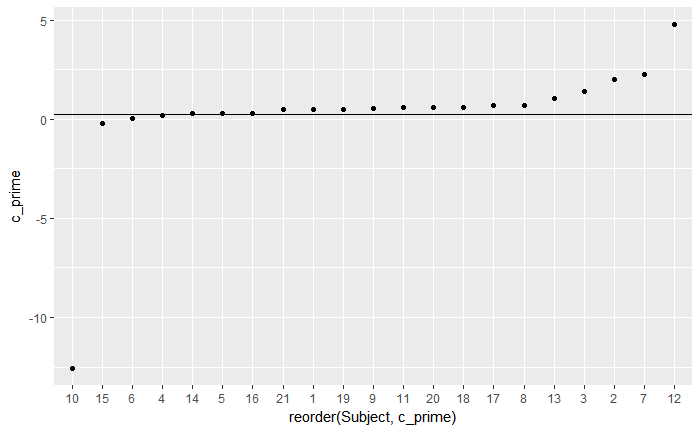

```r
ggplot(d_prime_MLE, aes(x = reorder(Subject, c_prime), y = c_prime))+
  geom_point() +
  geom_hline(yintercept = mean(d_prime_MLE$c_prime))
```

As we can see we have one person there who has a negative d_prime and a strongly negative c_prime.

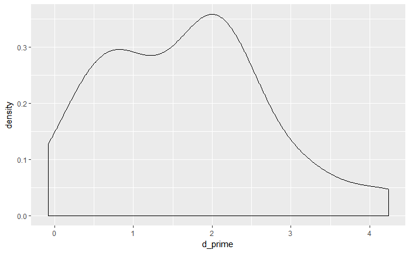

```r
ggplot(d_prime_MLE, aes(x = d_prime))+geom_density()
```

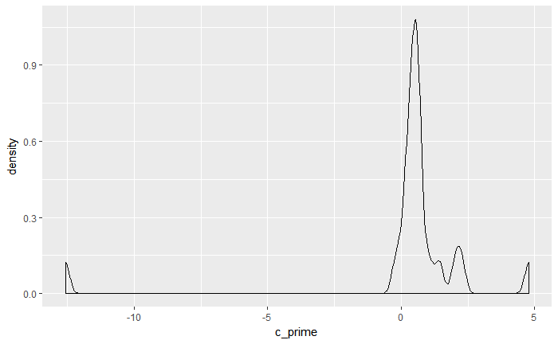

```r
ggplot(d_prime_MLE, aes(x = c_prime))+geom_density()
```

# Building a Stan model

Let’s go back to our data before we added a constant to it to deal with floor and ceiling effects - we won’t need that for Stan.

```r
stan_counts <- test_data %>%
  group_by(Subject, Touch) %>%
  summarise(totals = sum(Reported), trial_count = n())
stan_counts
```

| Subject | Touch | totals | trial_count |
| --- | --- | --- | --- |
| 1 | Touch | 26 | 51 |
| 1 | No touch | 1 | 51 |
| 2 | Touch | 9 | 51 |
| 2 | No touch | 3 | 51 |
| 3 | Touch | 18 | 51 |
| 3 | No touch | 11 | 51 |
| 4 | Touch | 35 | 51 |
| 4 | No touch | 6 | 51 |
| 5 | Touch | 37 | 51 |
| 5 | No touch | 0 | 51 |

[output cut: 32 more lines]

To keep it super simple, let’s start off estimating hit rate only

```r
hits_only <- filter(stan_counts, Touch == "Touch")
hits_pooled <- list(N = dim(hits_only)[1],  # 21 participants
                   y = hits_only$totals, #total responses
                   K = hits_only$trial_count) #total trial
```

## Complete pooling

Now we set up a simple Stan model, with complete pooling.

[output not shown]

```r
fit_hits <- sampling(hits_cp, data = hits_pooled)
```

[output not shown]

[output cut: 38 more lines]

[output not shown]

```r
fit_hits
```

```
Inference for Stan model: stan-8f8309a5c87.
4 chains, each with iter=2000; warmup=1000; thin=1;
post-warmup draws per chain=1000, total post-warmup draws=4000.

        mean se_mean   sd    2.5%     25%     50%     75%   97.5% n_eff Rhat
phi     0.47    0.00 0.02    0.44    0.46    0.47    0.48    0.50  1454    1
lp__ -742.31    0.02 0.74 -744.46 -742.46 -742.02 -741.84 -741.78  1732    1

Samples were drawn using NUTS(diag_e) at Sun Aug 13 13:57:34 2017.
For each parameter, n_eff is a crude measure of effective sample size,
and Rhat is the potential scale reduction factor on split chains (at
convergence, Rhat=1).
```

This is a “complete pooling” estimate of the hit rate.

## No pooling

Next we make a model with no pooling - an estimate for each individual.

[output not shown]

```r
no_pool_fit <- sampling(no_pool_hits, data = hits_pooled)
```

[output not shown]

[output cut: 38 more lines]

[output not shown]

```r
no_pool_fit
```

```
Inference for Stan model: stan-8f842c410f0.
4 chains, each with iter=2000; warmup=1000; thin=1;
post-warmup draws per chain=1000, total post-warmup draws=4000.

             mean se_mean   sd    2.5%     25%     50%     75%   97.5% n_eff Rhat
theta[1]     0.51    0.00 0.07    0.38    0.47    0.51    0.56    0.64  4000    1
theta[2]     0.19    0.00 0.05    0.09    0.15    0.18    0.22    0.30  4000    1
theta[3]     0.36    0.00 0.07    0.23    0.31    0.36    0.40    0.49  4000    1
theta[4]     0.68    0.00 0.06    0.55    0.64    0.68    0.72    0.79  4000    1
theta[5]     0.72    0.00 0.06    0.59    0.68    0.72    0.76    0.83  4000    1
theta[6]     0.96    0.00 0.03    0.90    0.95    0.97    0.98    1.00  4000    1
theta[7]     0.15    0.00 0.05    0.07    0.12    0.15    0.18    0.26  4000    1
theta[8]     0.34    0.00 0.06    0.22    0.30    0.34    0.38    0.47  4000    1
theta[9]     0.45    0.00 0.07    0.33    0.41    0.45    0.50    0.59  4000    1
theta[10]    0.15    0.00 0.05    0.07    0.12    0.15    0.18    0.26  4000    1
theta[11]    0.43    0.00 0.07    0.30    0.39    0.43    0.48    0.57  4000    1
theta[12]    0.04    0.00 0.03    0.00    0.02    0.03    0.05    0.10  4000    1
theta[13]    0.30    0.00 0.06    0.19    0.26    0.30    0.34    0.43  4000    1
theta[14]    0.70    0.00 0.06    0.57    0.66    0.70    0.74    0.81  4000    1
theta[15]    0.98    0.00 0.02    0.93    0.97    0.99    0.99    1.00  4000    1
theta[16]    0.64    0.00 0.06    0.51    0.60    0.64    0.69    0.76  4000    1
theta[17]    0.43    0.00 0.07    0.30    0.39    0.43    0.48    0.57  4000    1
theta[18]    0.42    0.00 0.07    0.29    0.37    0.42    0.46    0.55  4000    1
theta[19]    0.49    0.00 0.07    0.36    0.44    0.49    0.54    0.62  4000    1
theta[20]    0.43    0.00 0.07    0.31    0.39    0.43    0.48    0.57  4000    1
theta[21]    0.51    0.00 0.07    0.38    0.46    0.51    0.56    0.64  4000    1
lp__      -627.73    0.09 3.38 -635.60 -629.77 -627.39 -625.32 -622.25  1512    1

Samples were drawn using NUTS(diag_e) at Sun Aug 13 13:59:28 2017.
For each parameter, n_eff is a crude measure of effective sample size,
and Rhat is the potential scale reduction factor on split chains (at
convergence, Rhat=1).
```

```
ci_level: 0.8 (80% intervals)
outer_level: 0.95 (95% intervals)
```

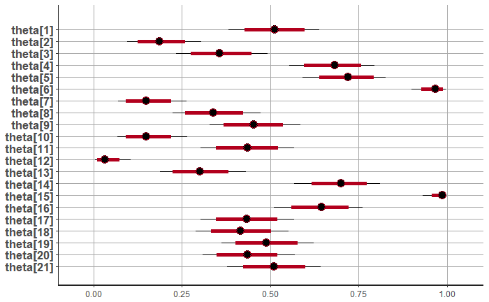

```r
stan_plot(no_pool_fit, pars = "theta")
```

Now there are 21 individual parameters, one for each subject and their hit-rate.

## Partial pooling

Our final model will attempt to use information each parameter to inform the other parameters.

[output not shown]

```r
hits_pp <- sampling(part_pool, data = hits_pooled)
```

[output not shown]

[output cut: 38 more lines]

[output not shown]

```r
hits_pp
```

```
Inference for Stan model: stan-8f84e956aa3.
4 chains, each with iter=2000; warmup=1000; thin=1;
post-warmup draws per chain=1000, total post-warmup draws=4000.

             mean se_mean   sd    2.5%     25%     50%     75%   97.5% n_eff Rhat
phi          0.49    0.00 0.06    0.37    0.45    0.49    0.54    0.62  4000    1
kappa        2.09    0.01 0.64    1.12    1.63    2.00    2.46    3.56  2805    1
theta[1]     0.51    0.00 0.07    0.37    0.46    0.51    0.56    0.65  4000    1
theta[2]     0.19    0.00 0.06    0.09    0.15    0.19    0.22    0.31  4000    1
theta[3]     0.36    0.00 0.07    0.23    0.31    0.36    0.40    0.49  4000    1
theta[4]     0.68    0.00 0.06    0.55    0.64    0.68    0.72    0.79  4000    1
theta[5]     0.72    0.00 0.06    0.59    0.68    0.72    0.76    0.83  4000    1
theta[6]     0.96    0.00 0.03    0.89    0.95    0.97    0.98    1.00  4000    1
theta[7]     0.15    0.00 0.05    0.07    0.12    0.15    0.18    0.26  4000    1
theta[8]     0.34    0.00 0.06    0.22    0.30    0.34    0.38    0.47  4000    1
theta[9]     0.45    0.00 0.07    0.32    0.41    0.45    0.50    0.59  4000    1
theta[10]    0.15    0.00 0.05    0.07    0.12    0.15    0.18    0.26  4000    1
theta[11]    0.44    0.00 0.07    0.31    0.39    0.43    0.48    0.57  4000    1
theta[12]    0.04    0.00 0.03    0.01    0.02    0.03    0.05    0.10  4000    1
theta[13]    0.30    0.00 0.06    0.19    0.26    0.30    0.34    0.43  4000    1
theta[14]    0.70    0.00 0.06    0.57    0.66    0.70    0.74    0.81  4000    1
theta[15]    0.98    0.00 0.02    0.93    0.97    0.99    0.99    1.00  4000    1
theta[16]    0.64    0.00 0.07    0.50    0.59    0.64    0.69    0.77  4000    1
theta[17]    0.43    0.00 0.07    0.31    0.39    0.43    0.48    0.57  4000    1
theta[18]    0.42    0.00 0.07    0.29    0.37    0.41    0.46    0.55  4000    1
theta[19]    0.49    0.00 0.07    0.36    0.44    0.49    0.54    0.63  4000    1
theta[20]    0.43    0.00 0.07    0.31    0.39    0.43    0.48    0.57  4000    1
theta[21]    0.51    0.00 0.07    0.38    0.46    0.51    0.55    0.64  4000    1
lp__      -631.98    0.09 3.63 -639.94 -634.17 -631.67 -629.35 -625.90  1704    1

Samples were drawn using NUTS(diag_e) at Sun Aug 13 14:00:31 2017.
For each parameter, n_eff is a crude measure of effective sample size,
and Rhat is the potential scale reduction factor on split chains (at
convergence, Rhat=1).
```

```
ci_level: 0.8 (80% intervals)
outer_level: 0.95 (95% intervals)
```

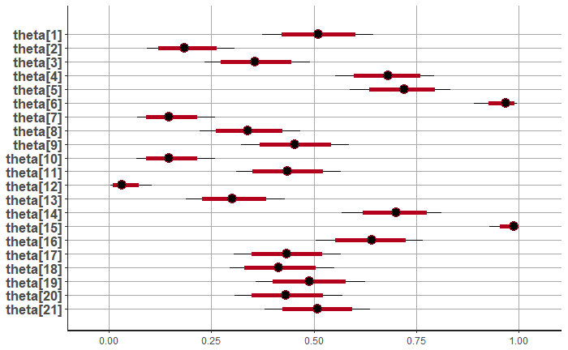

```r
stan_plot(hits_pp, pars = "theta")
```

```
ci_level: 0.8 (80% intervals)
outer_level: 0.95 (95% intervals)
```

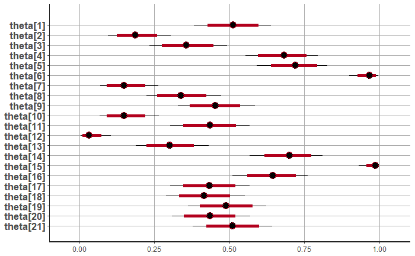

```r
stan_plot(no_pool_fit, pars = "theta")
```

In this case the pooling seems to have made very little difference - this is a fully balanced design so there is probably very little to be done.

### log-odds prior

Didnt’ full understand the last prior, so here’s one with log-odds.

```r
hits_log_odds <- sampling(log_odds, data = hits_pooled)
```

[output not shown]

[output cut: 38 more lines]

[output not shown]

```r
hits_log_odds
```

```
Inference for Stan model: stan-8f866e7587d.
4 chains, each with iter=2000; warmup=1000; thin=1;
post-warmup draws per chain=1000, total post-warmup draws=4000.

             mean se_mean   sd    2.5%     25%     50%     75%   97.5% n_eff Rhat
mu          -0.18    0.01 0.34   -0.87   -0.40   -0.17    0.04    0.47  4000    1
sigma        1.56    0.00 0.28    1.08    1.36    1.53    1.72    2.18  4000    1
alpha[1]     0.03    0.00 0.27   -0.51   -0.16    0.03    0.21    0.56  4000    1
alpha[2]    -1.50    0.01 0.35   -2.20   -1.72   -1.49   -1.26   -0.86  4000    1
alpha[3]    -0.60    0.00 0.28   -1.17   -0.79   -0.60   -0.41   -0.05  4000    1
alpha[4]     0.76    0.00 0.29    0.20    0.57    0.75    0.95    1.36  4000    1
alpha[5]     0.95    0.00 0.31    0.37    0.73    0.94    1.15    1.58  4000    1
alpha[6]     3.14    0.01 0.66    2.01    2.67    3.08    3.55    4.59  4000    1
alpha[7]    -1.78    0.01 0.38   -2.58   -2.02   -1.76   -1.51   -1.06  4000    1
alpha[8]    -0.68    0.00 0.29   -1.26   -0.88   -0.67   -0.49   -0.11  4000    1
alpha[9]    -0.20    0.00 0.29   -0.76   -0.39   -0.20    0.00    0.34  4000    1
alpha[10]   -1.77    0.01 0.38   -2.58   -2.01   -1.75   -1.52   -1.06  4000    1
alpha[11]   -0.28    0.00 0.28   -0.81   -0.47   -0.28   -0.09    0.27  4000    1
alpha[12]   -3.22    0.01 0.68   -4.72   -3.64   -3.16   -2.74   -2.04  4000    1
alpha[13]   -0.87    0.00 0.31   -1.47   -1.08   -0.86   -0.65   -0.29  4000    1
alpha[14]    0.85    0.00 0.31    0.26    0.63    0.84    1.06    1.47  4000    1
alpha[15]    3.67    0.01 0.86    2.28    3.06    3.56    4.16    5.63  4000    1
alpha[16]    0.59    0.00 0.28    0.06    0.39    0.59    0.78    1.16  4000    1
alpha[17]   -0.28    0.00 0.28   -0.83   -0.47   -0.28   -0.09    0.25  4000    1
alpha[18]   -0.36    0.00 0.28   -0.91   -0.55   -0.36   -0.17    0.18  4000    1
alpha[19]   -0.04    0.00 0.28   -0.58   -0.23   -0.04    0.15    0.48  4000    1
alpha[20]   -0.28    0.00 0.28   -0.83   -0.47   -0.27   -0.08    0.27  4000    1
alpha[21]    0.04    0.00 0.28   -0.51   -0.15    0.03    0.22    0.60  4000    1
lp__      -610.28    0.08 3.49 -618.12 -612.53 -609.98 -607.78 -604.41  1685    1

Samples were drawn using NUTS(diag_e) at Sun Aug 13 14:01:47 2017.
For each parameter, n_eff is a crude measure of effective sample size,
and Rhat is the potential scale reduction factor on split chains (at
convergence, Rhat=1).
```

```
ci_level: 0.8 (80% intervals)
outer_level: 0.95 (95% intervals)
```

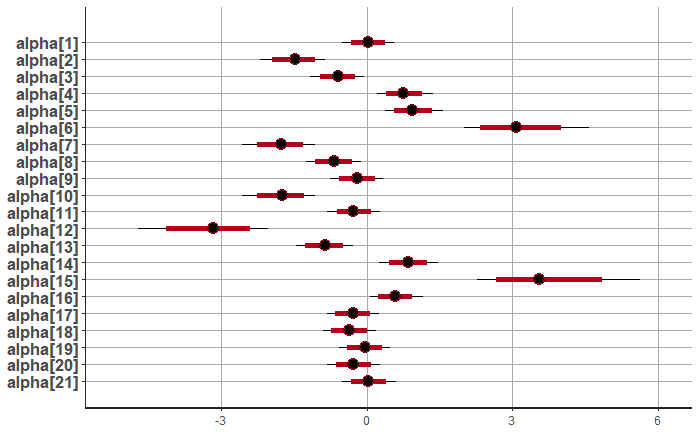

```r
stan_plot(hits_log_odds, pars = "alpha")
```

```
ci_level: 0.8 (80% intervals)
outer_level: 0.95 (95% intervals)
```

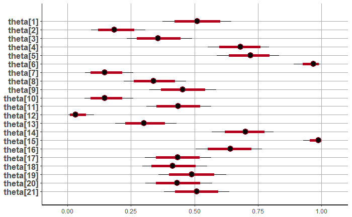

```r
stan_plot(hits_pp, pars = "theta")
```

## comparison of pooled versus no pooled, versus MLE

```r
summary(hits_log_odds, pars = "alpha")$summary[,1]
```

```
   alpha[1]    alpha[2]    alpha[3]    alpha[4]    alpha[5]    alpha[6]    alpha[7]    alpha[8]    alpha[9]
 0.02947895 -1.49918532 -0.60358638  0.76075269  0.94603716  3.14071732 -1.77624365 -0.68237733 -0.19919083
  alpha[10]   alpha[11]   alpha[12]   alpha[13]   alpha[14]   alpha[15]   alpha[16]   alpha[17]   alpha[18]
-1.77468184 -0.27535999 -3.22483045 -0.86990244  0.84912308  3.66985915  0.58735427 -0.27996274 -0.35961224
  alpha[19]   alpha[20]   alpha[21]
-0.04455912 -0.27806733  0.03528651
```

```r
d_prime_MLE$hits_log <- summary(hits_log_odds, pars = "alpha")$summary[,1]
d_prime_MLE$hits_inv <- exp(d_prime_MLE$hits_log)/(1+exp(d_prime_MLE$hits_log))
d_prime_MLE
```

| Subject | Touch | No touch | d_prime | c_raw | c_prime | hits_log | hits_inv |
| --- | --- | --- | --- | --- | --- | --- | --- |
| 1 | 0.50961538 | 0.028846154 | 1.92213318 | 0.9369621 | 0.48745949 | 0.02947895 | 0.50736920 |
| 2 | 0.18269231 | 0.067307692 | 0.59099440 | 1.2006497 | 2.03157538 | -1.49918532 | 0.18254706 |
| 3 | 0.35576923 | 0.221153846 | 0.39851148 | 0.5690464 | 1.42792980 | -0.60358638 | 0.35352362 |
| 4 | 0.68269231 | 0.125000000 | 1.62559013 | 0.3375543 | 0.20765032 | 0.76075269 | 0.68151713 |
| 5 | 0.72115385 | 0.009615385 | 2.92729979 | 0.8773772 | 0.29972237 | 0.94603716 | 0.72031752 |
| 6 | 0.97115385 | 0.009615385 | 4.23905579 | 0.2214992 | 0.05225202 | 3.14071732 | 0.95854140 |
| 7 | 0.14423077 | 0.048076923 | 0.60229016 | 1.3626477 | 2.26244393 | -1.77624365 | 0.14476759 |
| 8 | 0.33653846 | 0.009615385 | 1.91909825 | 1.3814780 | 0.71985789 | -0.68237733 | 0.33573091 |
| 9 | 0.45192308 | 0.009615385 | 2.22022298 | 1.2309156 | 0.55441082 | -0.19919083 | 0.45036629 |
| 10 | 0.14423077 | 0.163461538 | -0.08117228 | 1.0209165 | -12.57715716 | -1.77468184 | 0.14496106 |

[output cut: 11 more lines]

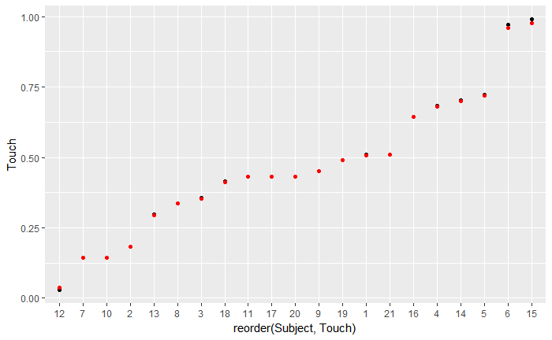

```r
ggplot(d_prime_MLE, aes(x = reorder(Subject, Touch), y = Touch)) + geom_point() +
         geom_point(aes(x = reorder(Subject, Touch), y = hits_inv), colour = "red")
```

Virtually no difference in this case.

# Factorial model including false alarms.

```r
stan_counts
```

[output not shown]

```r
all_data <- list(N = dim(stan_counts)[1],
                 K = stan_counts$trial_count,
                 y = stan_counts$totals,
                 preds = model.matrix(~Touch,stan_counts),
                 npar = 2,
                 J_1 = stan_counts$Subject)
all_data
```

```
$N
[1] 42

$K
 [1] 51 51 51 51 51 51 51 51 51 51 51 51 51 51 51 51 51 51 51 51 51 51 51 51 51 51 51 51 51 51 51 51 51 51 51 51
[37] 51 51 51 51 51 51

$y
 [1] 26  1  9  3 18 11 35  6 37  0 50  0  7  2 17  0 23  0  7  8 22  0  1  0 15  3 36  1 51  8 33  3 22  7 21  0
[37] 25  4 22  0 26  9

$preds
   (Intercept) TouchNo touch
1            1             0
2            1             1
```

[output cut: 53 more lines]

Let’s now try to expand this to a design with a factor.

[output not shown]

```r
fac_fit <- sampling(hits_and_FAs, data = all_data)
```

[output not shown]

```r
fac_fit
```

```
Stan model 'stan-8f8358d6ebb' does not contain samples.
```